# Weekly Energy Charts

May 27, 2022

[Sign up here to get on our email list](https://docs.google.com/forms/d/e/1FAIpQLSckqeGjUvIlhveVyjmkXe913tzQRLANqPNQzEZTUQD2hQxH8g/viewform?usp=pp_url)

# Featured Stories

## Deloitte’s Global Turning Point Report

#### Debosree Mukherjee

The effects of climate change have already started taking place around the world. A recent Deloitte survey done in [23 countries with over 23,000 respondents](https://www.weforum.org/agenda/2022/05/one-more-reason-for-rapid-climate-action-economics/) discovered that more than half experienced climate-related extreme weather events recently. A new [report from the Deloitte Economics Institute](https://www2.deloitte.com/global/en/pages/about-deloitte/articles/global-turning-point.html) argues that climate inaction could lead to the global average temperature rising by 3°C by the end of the century, well-above the goals set out in the Paris Agreement, and predicts major economic costs from such an outcome.

Deloitte’s analysis discusses two bookend scenarios

- Scenario A - allow global greenhouse gas emissions to rise.
- Scenario B - decarbonize our economy by mid-century.

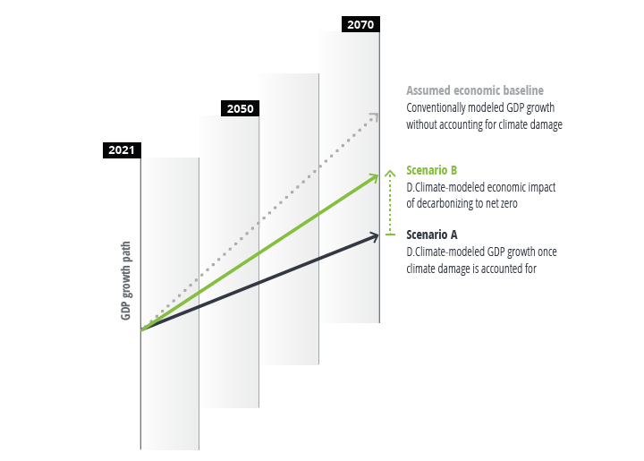

In scenario B, Deloitte finds that rapid efforts could lead to achieving global net zero emissions by 2050, limiting global warming to close to 1.5°C. If this is achieved, the global economy could see a gain of US$43 trillion by 2070. The report finds that there will be a period when investments in decarbonization would create temporary losses until the economy reaches a turning point where more rapid GDP growth will take hold. Different regions will reach the turning point at varying speed. However, all regions are expected to reach it before 2070. These economic benefits could also continue to grow beyond the modeled years.

Read the full report [here](https://www2.deloitte.com/global/en/pages/about-deloitte/articles/global-turning-point.html)

## Canada’s largest solar farm nears completion

#### [Yousaff Habib](https://www.linkedin.com/in/yousaff-habib-6684891a5/)

Alberta’s renewable energy supply will see huge boost when the [Travers Solar Project](https://www.traverssolar.com/) comes online in Fall 2022. The project will nearly double Alberta’s solar capacity. The project - the largest of its kind in Canada - has been in development since 2017. It spans 3300 acres using 1.3 million solar panels and will provide enough power for 150,000 homes once operational.

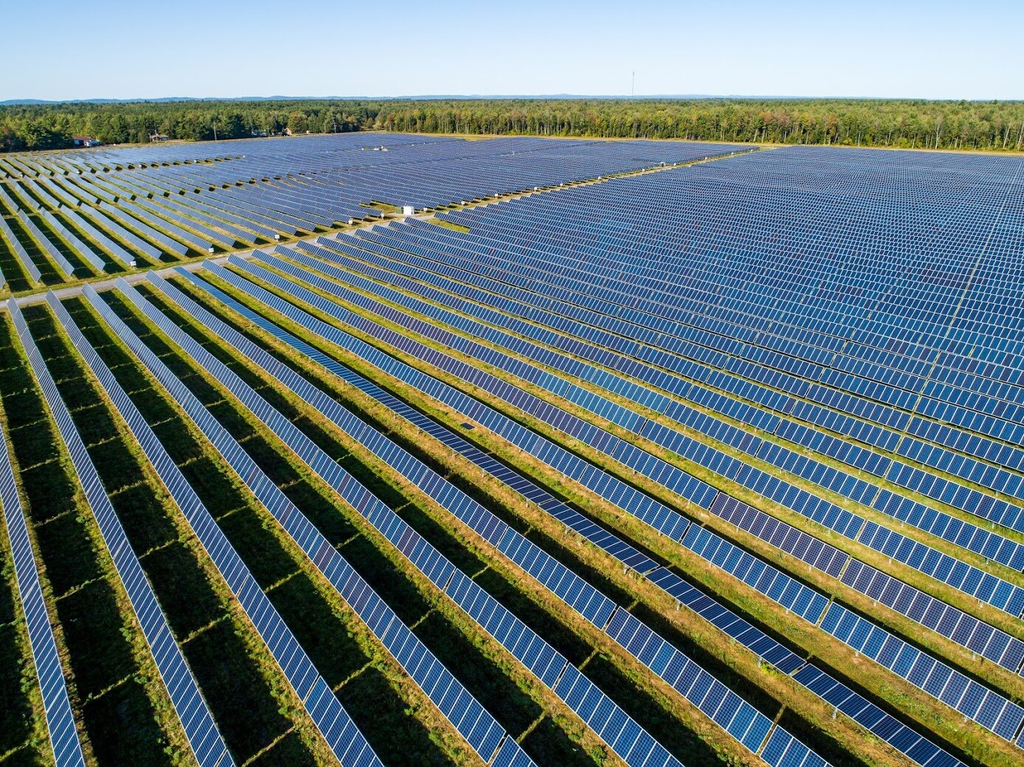

Travers Solar Panels Currently Installed

Alberta is a prime candidate for more solar energy investment, with a [competitive wholesale power market](https://www.alberta.ca/alberta-electricity-overview.aspx) and the [second highest potential for solar energy](https://solaralberta.ca/learn/why-go-solar/) generation in Canada. The Travers Solar Project drew [$700 million](https://www.power-technology.com/news/travers-solar-project/) from Danish energy investment firm Copenhagen Infrastructure Partners, and is among [many new privately-financed renewable energy developments in Canada](https://businessrenewables.ca/deal-tracker).

## Plastics in a Circular Economy

#### Keshinee Moonian

Numerous Canadian companies are trying to solve the plastic waste challenge.

Calgary-based Inter Pipeline, which spent $3 billion to develop the Heartland Petrochemical Complex (HPC), has committed to advancing a circular plastics economy in Canada. “We believe that plastic is a valuable commodity that belongs in the economy, not the environment,” says Lorraine Royer, InterPipeline’s director of government and stakeholder relations. “We look for solutions so that our impact is as little as it can be.”

A circular economy for plastics is an economic model where plastics never become waste, but rather are reused, recycled and recovered at the end of their life, according to Elena Mantagaris, vice-president of plastics with the Chemistry Industry Association of Canada (CIAC), of which Inter Pipeline is a member.

Inter Pipeline has partnered with the Northern Alberta Institute of Technology (NAIT) to create Plastics Research in Action (PRIA), with a mandate to study micro-plastics in water and to develop ways to use hard-to-recycle plastics in other products.

[New Alberta Plastics Plant Commits to Supporting a Circular Economy](https://energynow.ca/2022/05/new-alberta-plastics-plant-commits-to-supporting-a-circular-economy/)

# Oil

## Weekly Crude Prices

### Feature Crude

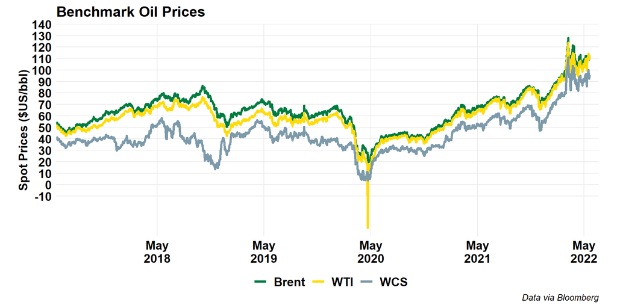

### Alberta Crude

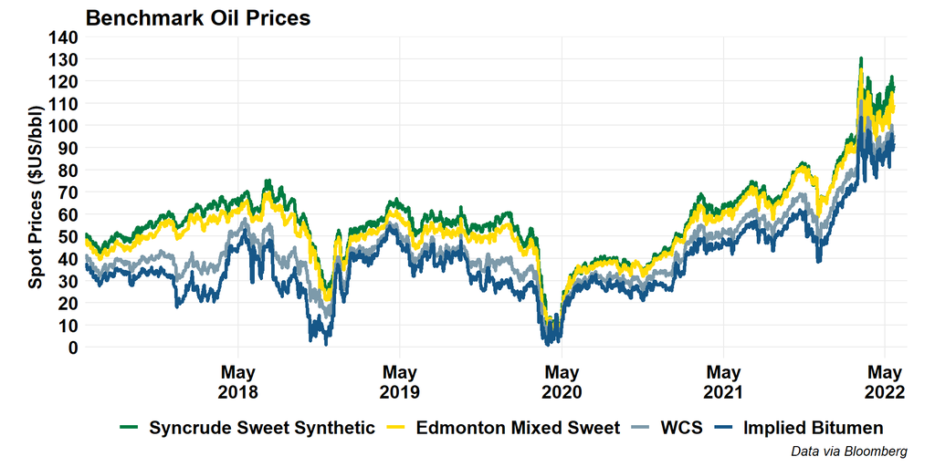

### US Crude

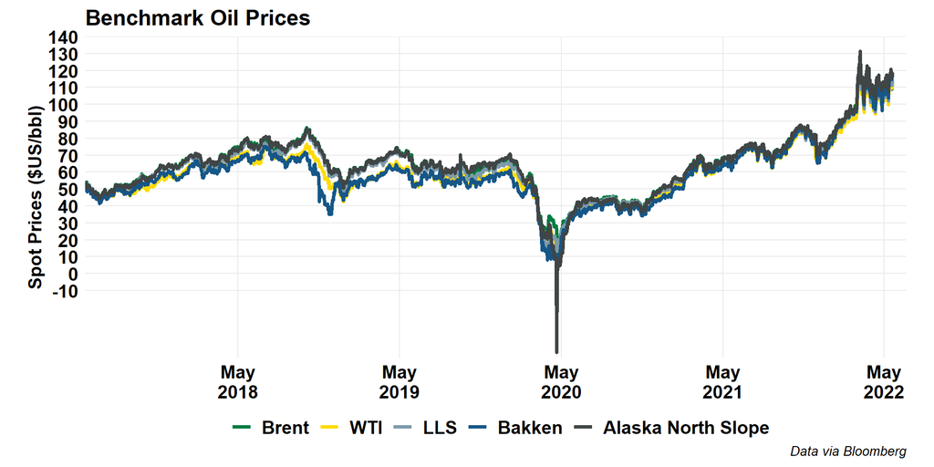

### Global Crude

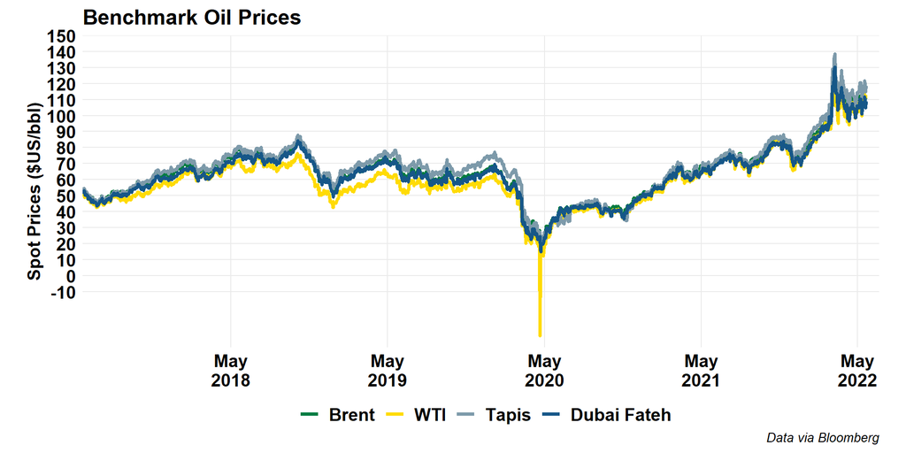

## Oil Price Differentials

### Brent-WTI

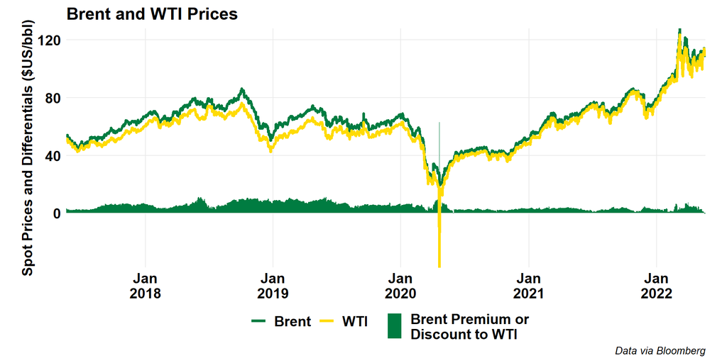

### WTI-WCS

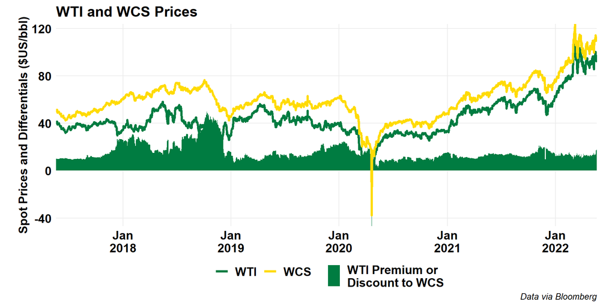

### Maya-WCS

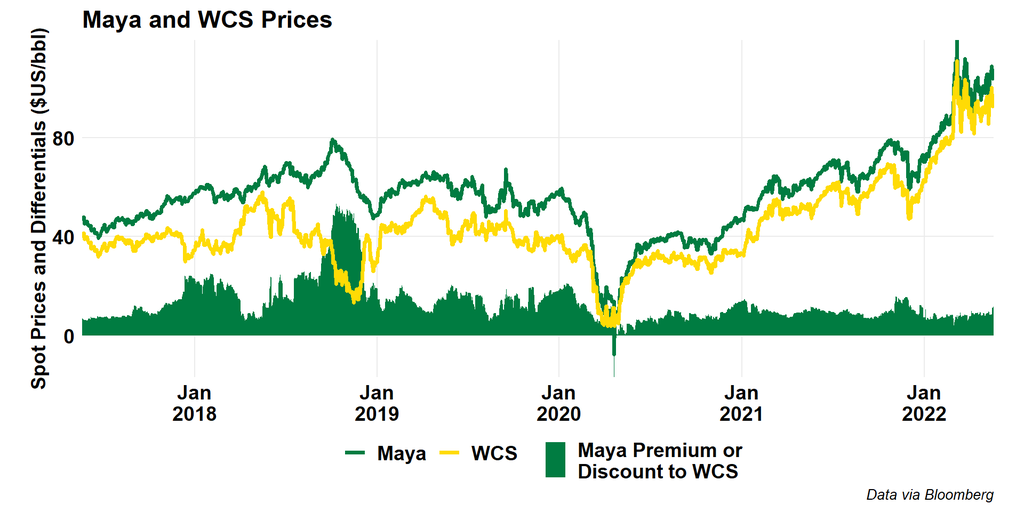

### WTI Cushing vs MEH

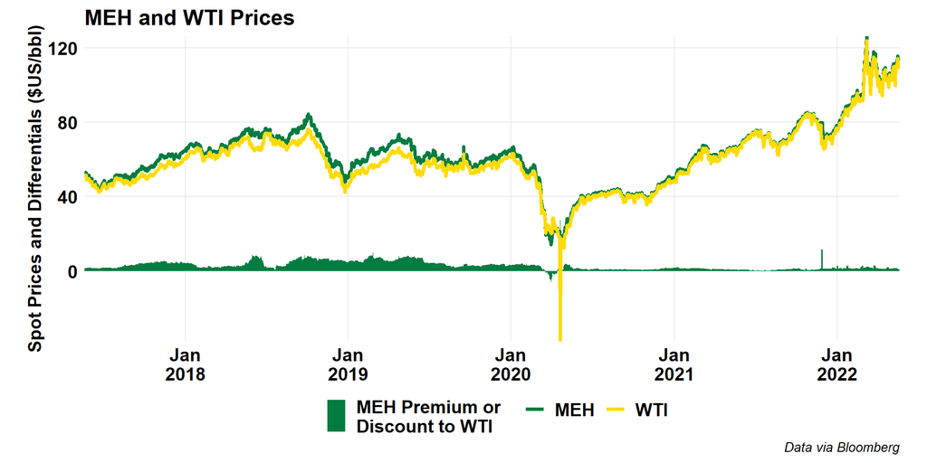

## Forward Curves

### WTI

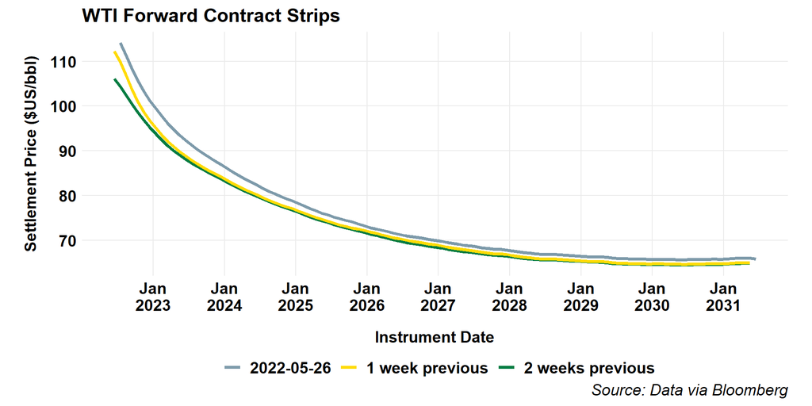

### Brent

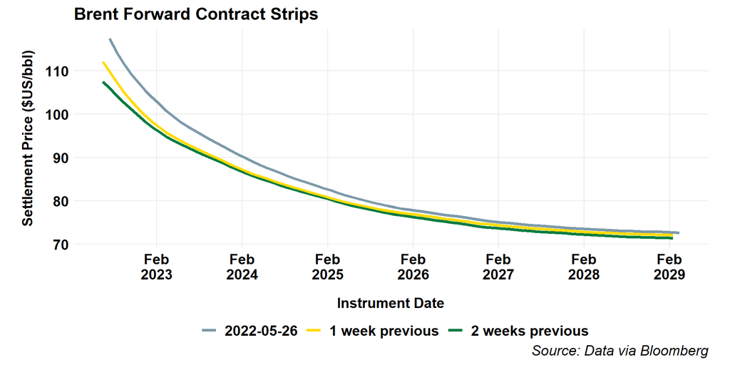

## Canadian Crude Supply and Disposition

### Production

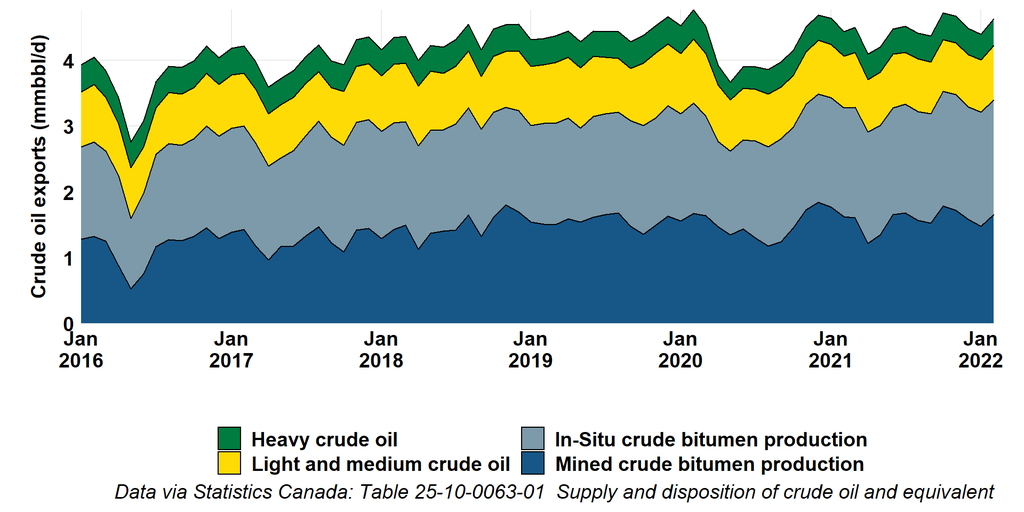

### Imports

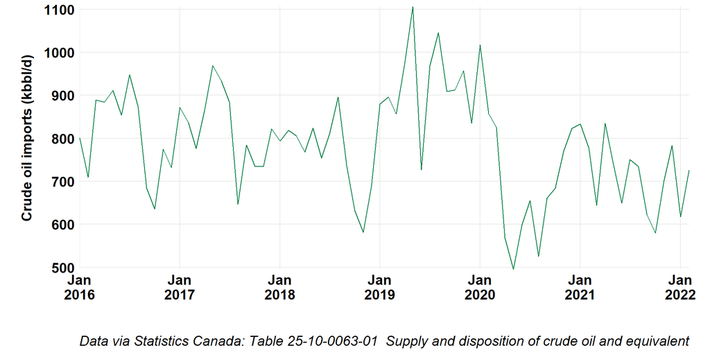

### Exports

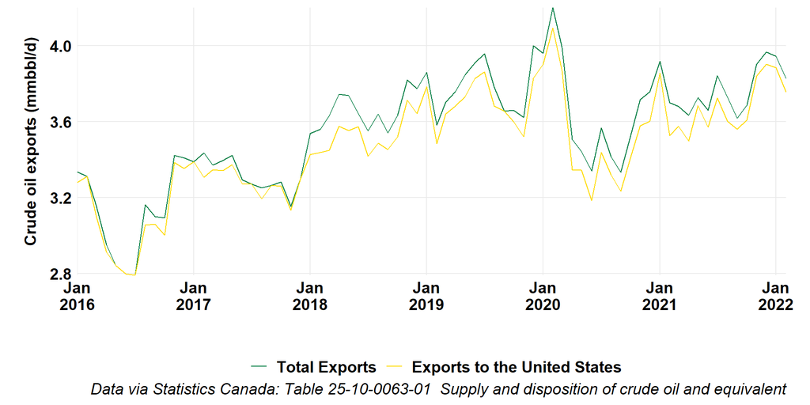

### Rail Exports

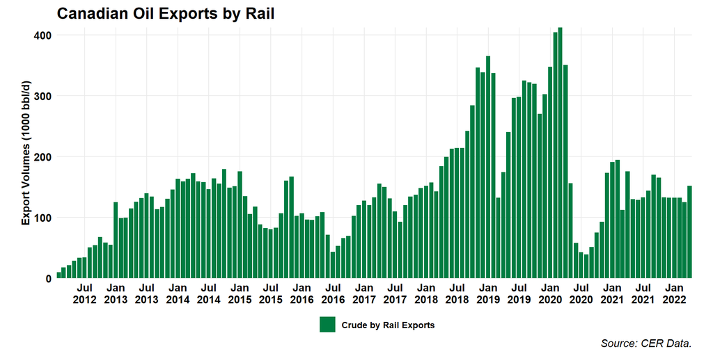

## US Oil

### Production

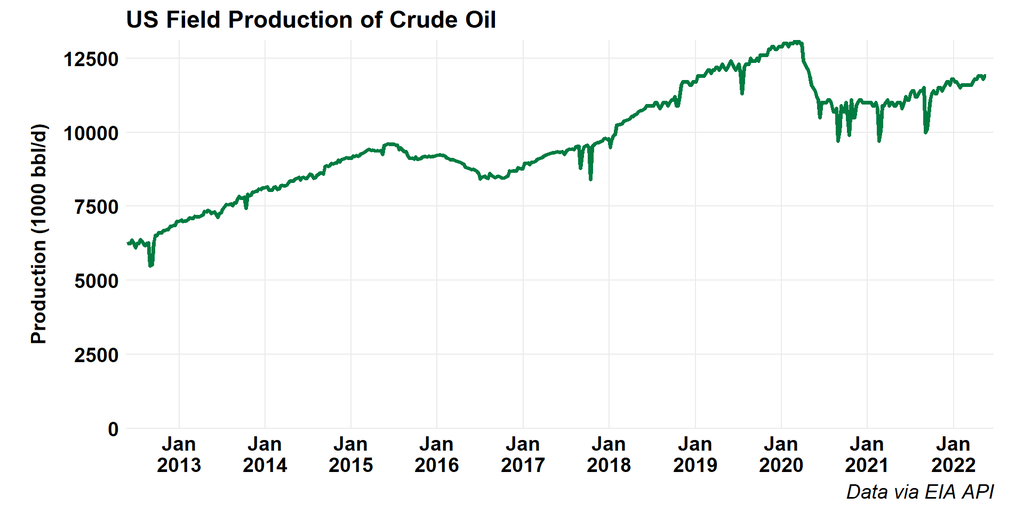

### LTO Production by Play

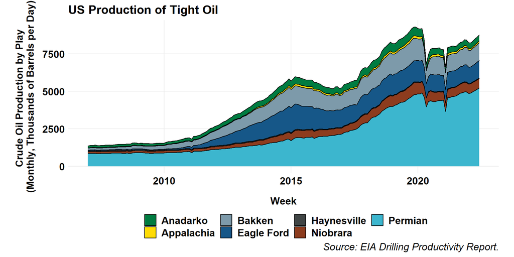

### Net Imports

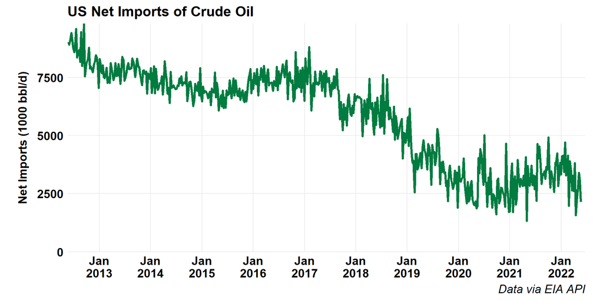

### Oil and Product Net Imports

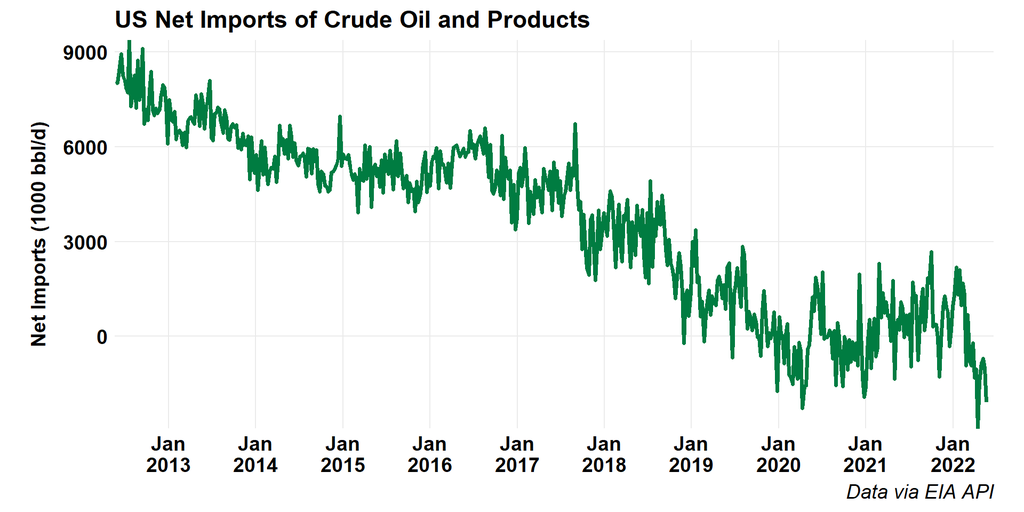

### Inventories

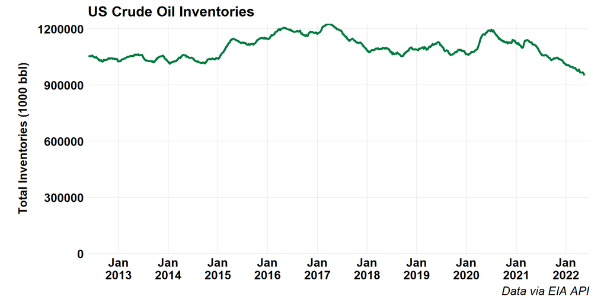

# Refined Products

## Canadian Gasoline Prices

### Map

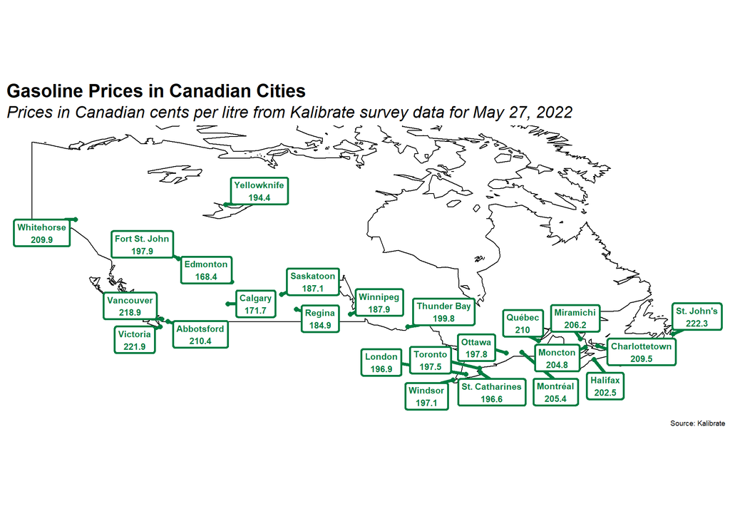

### Historic Gasoline Prices

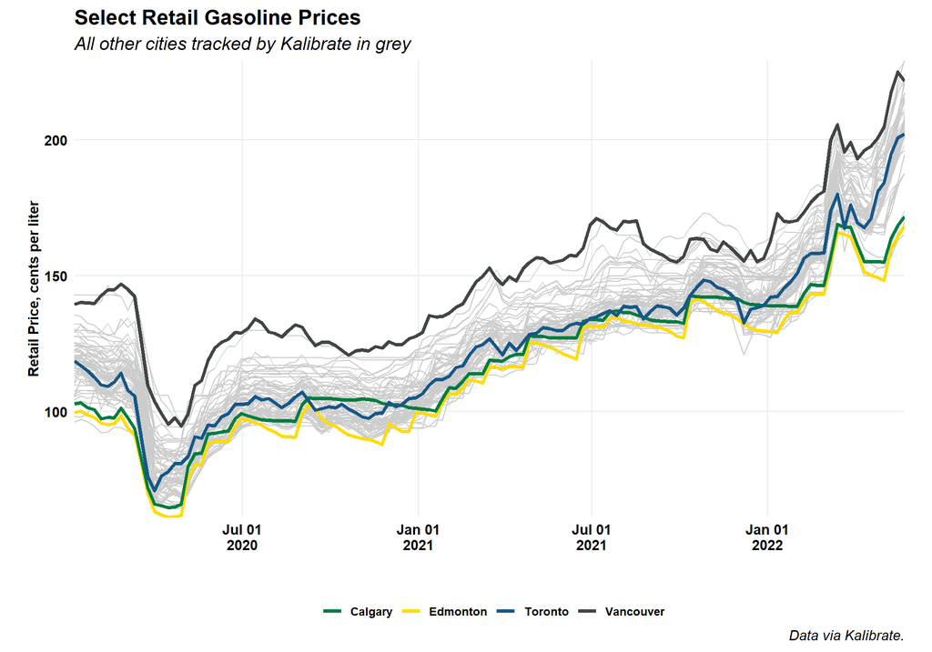

### Historic Diesel Prices

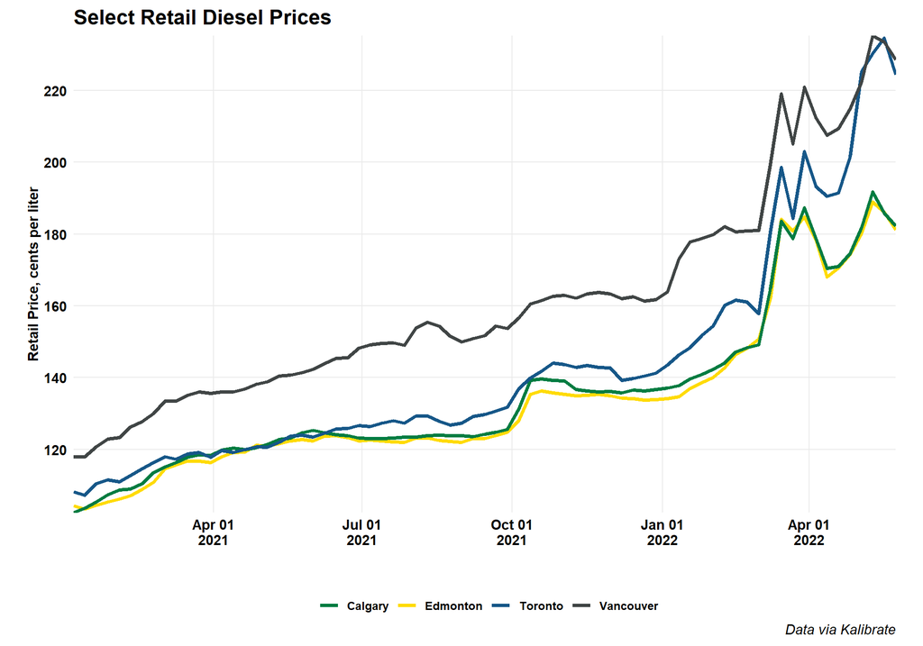

## Canadian Refinery Runs

### Canadian Refinery Runs

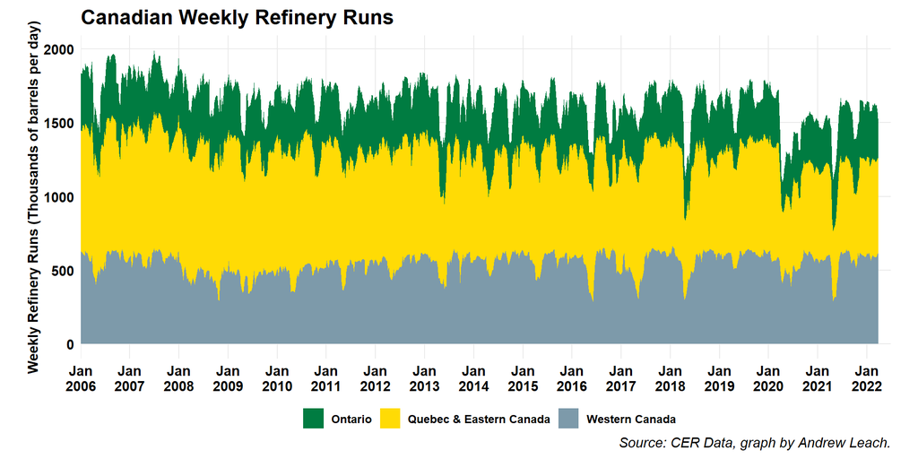

### Western Canada Refinery Runs

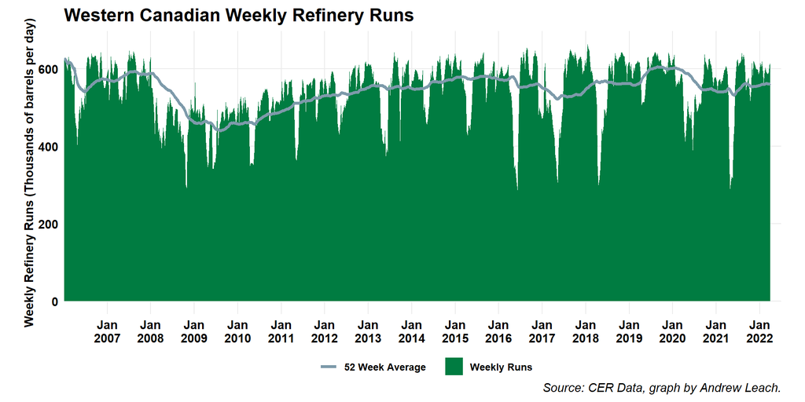

# Natural Gas

## Natural Gas Market Summary

### Feature Gas

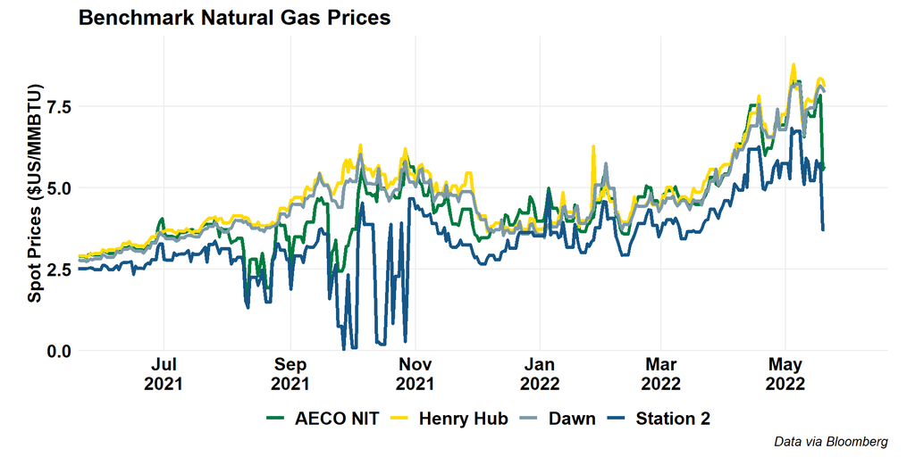

### Global Gas

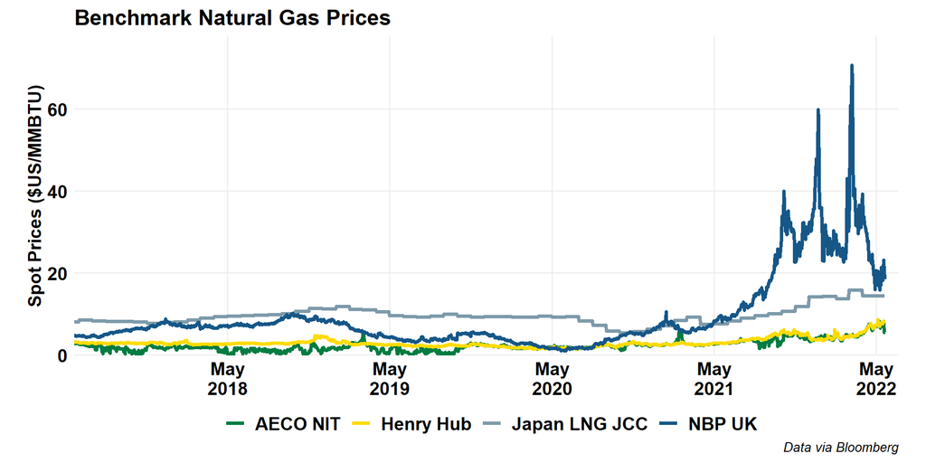

### North American Gas Hubs

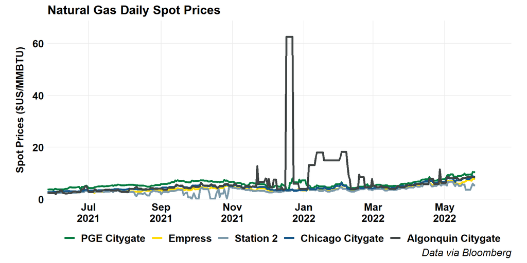

## Forward Prices

### Henry Hub

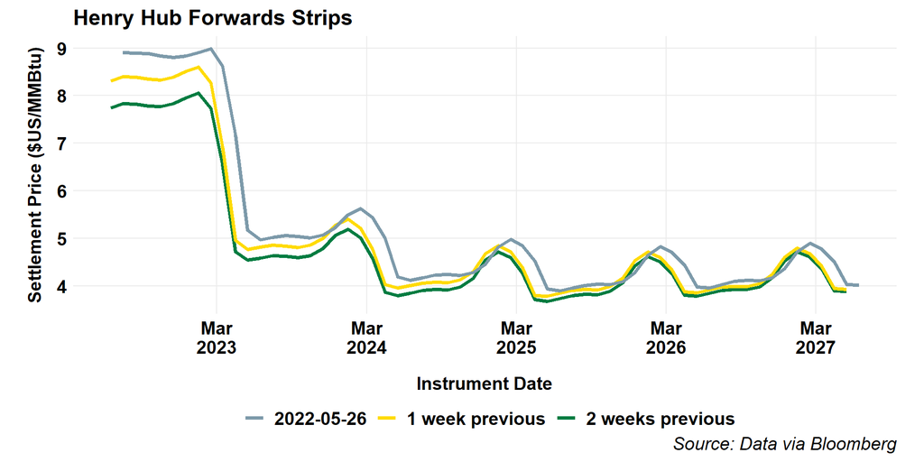

### Alberta (NIT) ($CAD)

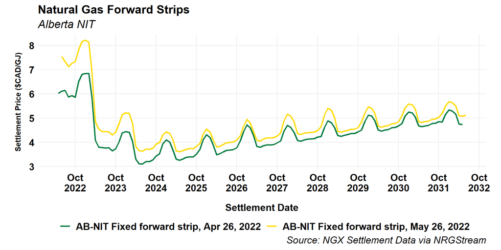

### Alberta (NIT)

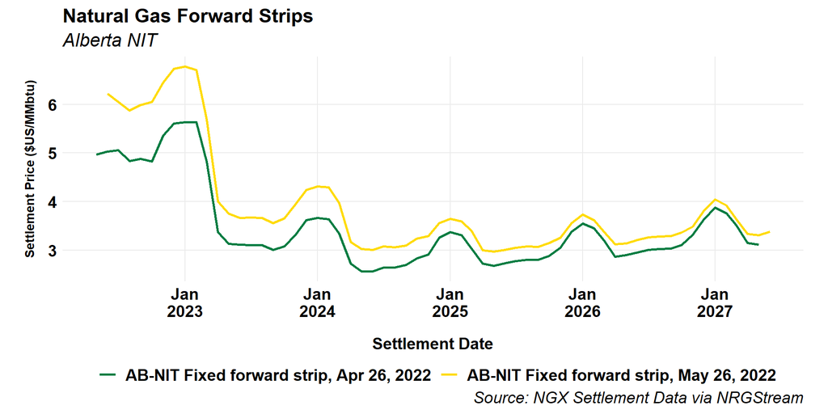